# Report: act_report

## WeRateDogs - DATA ANALYSIS

### Introduction

I'll be summarizing the analysis I did in my project notebook. The dataset that I analysed is the tweet archive of Twitter user [@dog_rates](https://twitter.com/dog_rates), also known as WeRateDogs. WeRateDogs is a Twitter account that rates people's dogs with a humorous comment about the dog. These ratings almost always have a denominator of 10. The numerators, though? Almost always greater than 10 (like 11/10, 12/10, 13/10, etc). Why? Because "they're good dogs Brent." WeRateDogs has over 4 million followers and has received international media coverage.

### Analysing the data

I have analysed the dataframes tweet_updated and image_updated and tweet_updated from the report after storing them into into a master .csv file – twitter_archive_master .csv. I have also analysed the data on 5 different questions of interest.

### 1. Comparison Of Average Rating Of Dog Stages

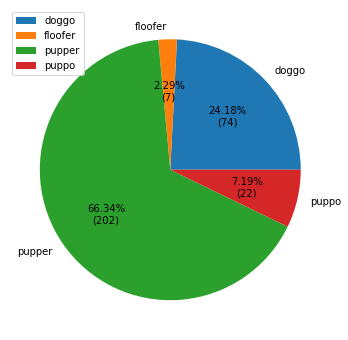

> ,

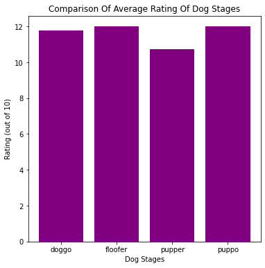

### 2. Most used Twitter source

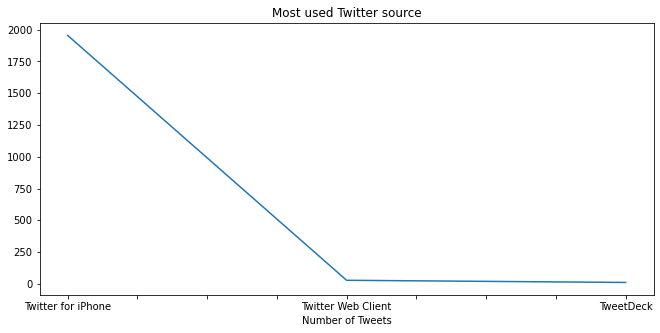

#### Observation:

> Most tweets (1955) were made using twitter for iPhone

### 3. Analysis of retweets and favorite counts

#### Dog image with the most favorite count

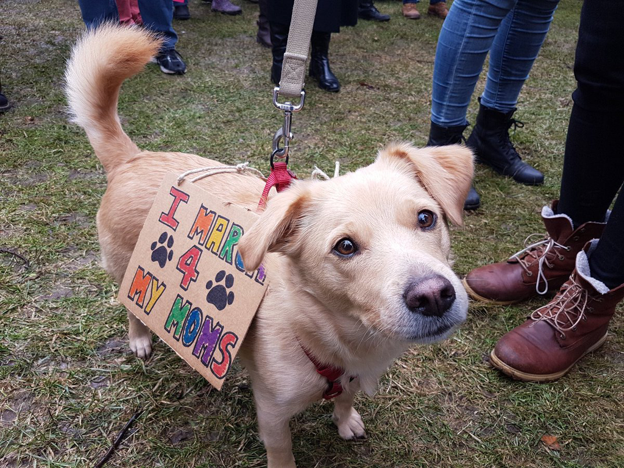

#### Observation:

> This picture of a puppo dog above is the image of the dog whose tweet generated the most favorite count

#### Image of the dog in the post that generated the most retweets

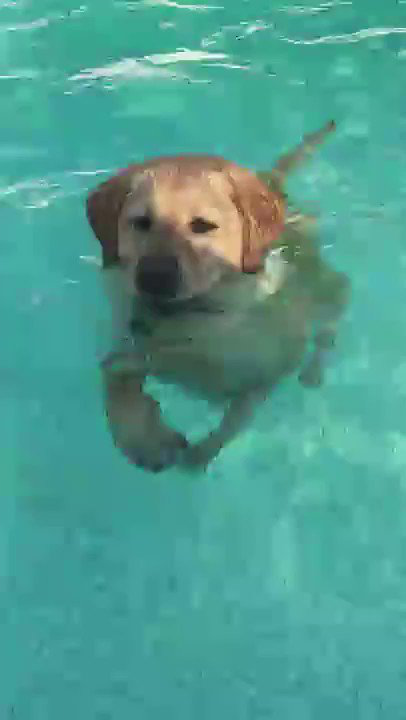

#### Observation:

> This tweet showing the image of a doggo in the pool generated the most retweets in this analysis

### 4. Which dog stage is the most common?

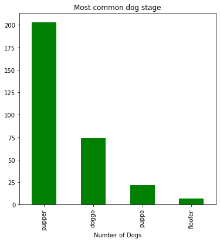

#### Observation:

> Pupper is the most common dog stage in on the WeRateDodgs twitter archive from 2015 up to August 1, 2017.

### 5. What are the top 3 most common dog names?

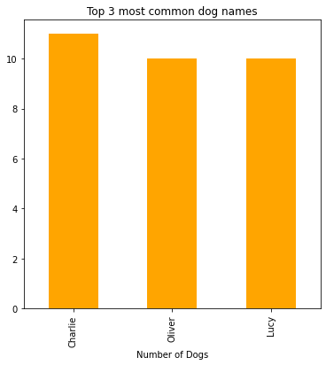

#### Observation:

> Charlie is the most common dog name closely followed by Oliver and Lucy.